# LHSP Data Tutorial

Today, we are working with the telomere distributions of nutritionally restricted Leach’s Storm-petrels. This is one treatment group of an experiment that sought to examine the effects of nutritional restriction and supplementation on telomere distrubtion and subsequent implications on longevity. This is only one of the treatment groups - the restricted birds. We don’t have other treatment groups to compare it do, but hypothesize that there will be normal distrubtion within this group due to similar environmental conditions.

```r
project_data <- read.csv("LHSPdata.csv")
#summary(project_data) # no point in showing summary statistics, they are incorrectly calculated
```

Since there are three telomere distribution measurements for each of the nine birds, we first create new variables averaging the three values.

```r
project_data <- mutate(project_data, X1 = ((project_data$X1a+project_data$X1b+project_data$X1c)/3))
project_data <- mutate(project_data, X2 = ((project_data$X2a+project_data$X2b+project_data$X2c)/3))
project_data <- mutate(project_data, X3 = ((project_data$X3a+project_data$X3b+project_data$X3c)/3))
project_data <- mutate(project_data, X4 = ((project_data$X4a+project_data$X4b+project_data$X4c)/3))
project_data <- mutate(project_data, X5 = ((project_data$X5a+project_data$X5b+project_data$X5c)/3))
project_data <- mutate(project_data, X6 = ((project_data$X6a+project_data$X6b+project_data$X6c)/3))
project_data <- mutate(project_data, X7 = ((project_data$X7a+project_data$X7b+project_data$X7c)/3))
project_data <- mutate(project_data, X8 = ((project_data$X8a+project_data$X8b+project_data$X8c)/3))
project_data <- mutate(project_data, X9 = ((project_data$X9a+project_data$X9b+project_data$X9c)/3))
```

Here are some functions created for this project that we will need to use, more on that later.

The data provided gives counts of telomeres (represented by optical density) at different points on a gel (distance given by a ladder). Because individual points have already been summed, we cannot treat the dataset as we might normally do in R. Summary statistics will treat the values for each test as values rather than counts. Therefore, we need to create our own methods for generating summary statistics such as mean and median.

```r
# How to use: assign to a variable (mean1 <- get_mean(DATA$LADDER, DATA$COLUMN)
# May need to log10 the variable
# Variable will represent the float actual mean
get_mean <- function(ladder, counts) {
  weighted <- (counts * ladder)
  mean <- sum(weighted)/sum(counts)
  return (mean)}
```

The get_median function will likely take a while to run. As mentioned earlier the raw data is actually in a summarized form. Counts are already calculated so this function needs to basically recreate the uncounted data then find the median by division. The get_median function accepts the parameters ladder and counts. The function then iterates through ladder and adds the ladder value to a list n times, where n is the associated number in counts. When the list is complete a variable called median_index is intialized as the length of the list / 2. If the list is odd the modulus of the operation will not be 0. Using that logic we can define two conditions for whether the list length is odd or even. If odd returns the middle index of the list. If even, average of the two middle members in the list.

```r
# How to use: assign to a variable (ie. median1 <- get_median(DATA$LADDER, DATA$COLUMN) )
# May need to log10 the variable later on
# Variable will represent the actual median
get_median <- function(ladder, counts) {
  full <- list()
  for (i in 1:length(ladder)) {
    adjust <- floor(counts[i])
    for (n in 1:adjust) {
      full <- list.append(full, ladder[i])}}

  mod <- (length(full) %% 2)
  median_index <- length(full) / 2
  if (mod != 0) {
    median_index <- median_index + 0.5
    return (as.numeric(as.character(unlist((full[median_index])))))
    }
  else {
    return ((as.numeric(as.character(unlist((full[median_index])))) + as.numeric(as.character(unlist((full[median_index + 1])))))/2)}}
```

The dataset has replicate measurements of each individual. Since we are interested in the means, we will need to calculate the average optical density (analagous to telomere counts) of the individuals at different distances on the ladder. Here we create a new dataframe called “avgs” which contains the average telomere count at each point of the ladder for each individual.

```r
avgs = list()
replicates = 3 #Change if not accurate
num = 1
for (i in 3:length(project_data)){ #If data does not begin @ third column change accordingly
  name = (paste0("X", num, sep =""))
  if (i %% replicates == 0) {
    avgs[name] <- (project_data[i] + project_data[i+1] + project_data[i+2]) / replicates #If more/less than 3 replicates change to match
    num = num + 1}}
avgs <- data.frame(matrix(unlist(avgs), nrow=length(avgs[[1]]), byrow=F)) #Convert data from list to dataframe
avgs$Ladder = project_data$Ladder
```

Exploratory data analysis for this dataset is a little different than it normally would be because counts have already been calculated. To see the distribution of the telomere sizes for a single individual we actually need to plot it. Using stat = “identity” allows us to tell R not to perform it’s default counting methods for the visualization.

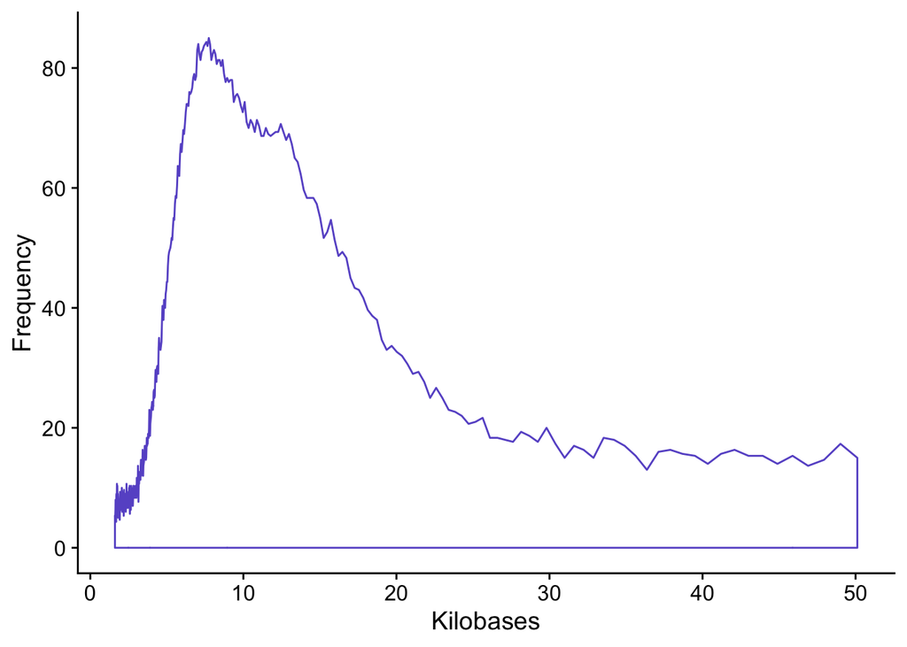

```r
ggplot(avgs) +
  geom_density(aes(x=Ladder, y=X1), fill="", color = "slateblue3", stat="identity", alpha=.3) +
  ylab("Frequency") + xlab("Kilobases") +
  theme_cowplot()
```

As we can see, this data has a strong right skew, which we will soon discuss.

In order to see some descriptive statistics, we first want to narrow down our dataframe. The select function allows us to only look at the few variables we want to visualize. Here, we are only interested in the average values that we calculated and plotted above, so we will create a new dataset from them. The next line of code allows us to check that we selected the correct data.

```r
LHSP.concise <- select(project_data, X1:X9)
LHSP.concise
```

```
##            X1        X2        X3        X4        X5        X6        X7
## 1   15.000000 17.666667 10.333333 10.666667 11.000000  8.333333 13.000000
## 2   17.333333 17.333333 13.333333 11.000000  8.333333  9.000000 12.333333
## 3   14.666667 17.666667 12.333333 12.333333  9.000000 11.000000 14.666667
## 4   13.666667 22.666667 11.333333  8.333333 10.333333 11.333333 13.333333
## 5   15.333333 20.666667 12.666667 10.333333 10.666667  9.333333 12.000000
## 6   14.000000 20.666667 11.333333 11.000000 11.000000  9.666667 13.666667
## 7   15.333333 22.333333 11.666667 11.333333 10.333333 10.666667 13.666667
## 8   15.333333 23.333333 14.000000 10.333333 10.666667 10.000000 14.333333
## 9   16.333333 23.333333 13.000000 10.000000 10.000000 12.000000 10.000000
## 10  15.666667 25.666667 11.000000 10.666667 10.000000 11.666667 13.333333
## 11  14.000000 25.333333 10.333333  9.333333 10.000000 10.333333 13.000000
## 12  15.333333 19.000000 14.333333  9.000000 12.000000 10.333333 14.000000
## 13  15.666667 15.000000 13.666667 11.333333 11.666667 11.000000 15.333333
## 14  16.333333 17.000000 11.333333 14.000000 10.333333 11.666667 14.000000
```

[output cut: 777 more lines]

In order to get a better description of how our data is distributed, we use the describe function below from the package “psych”. This lets us know important descriptive statistics like the mean and median. However, due to the nature of our data, these are not accurate representations of means and medians. That’s because the y axis is a frequency count rather than a simple variable.

```r
describe(avgs)
```

```
##        vars   n  mean    sd median trimmed   mad  min   max range skew kurtosis
## X1        1 395 29.77 26.04  17.00   26.50 14.33 4.33 85.00 80.67 0.88    -0.78
## X2        2 395 26.55 21.98  17.67   23.78 15.32 4.00 72.33 68.33 0.85    -0.76
## X3        3 395 29.30 25.19  16.67   26.60 14.83 2.33 79.67 77.33 0.78    -0.99
## X4        4 395 25.24 20.91  13.67   22.68 10.87 3.67 69.00 65.33 0.82    -0.84
## X5        5 395 25.24 18.57  16.33   23.39 11.86 4.00 60.67 56.67 0.76    -1.01
## X6        6 395 19.76 13.81  13.00   18.33  9.39 3.67 48.00 44.33 0.72    -1.00
## X7        7 395 32.11 26.37  19.00   29.36 17.30 5.00 84.00 79.00 0.73    -1.03
## X8        8 395 29.90 22.01  18.67   27.94 16.31 4.00 72.00 68.00 0.63    -1.16
## X9        9 395 29.90 26.07  15.67   26.14 12.85 3.67 91.00 87.33 1.00    -0.39
## X10      10 395 28.54 24.32  16.56   25.56 14.00 3.56 77.56 74.00 0.84    -0.86
## X11      11 395 23.41 17.66  14.44   21.43 10.54 5.22 57.89 52.67 0.77    -0.96
## X12      12 395 30.63 23.96  19.33   27.98 17.13 5.44 79.00 73.56 0.75    -0.94
## Ladder   13 395  8.54 10.09   4.06    6.15  2.87 1.61 50.11 48.50 2.17     4.22
##          se
## X1     1.31
## X2     1.11
## X3     1.27
## X4     1.05
## X5     0.93
## X6     0.69
## X7     1.33
## X8     1.11
## X9     1.31
## X10    1.22
## X11    0.89
## X12    1.21
## Ladder 0.51
```

Here is a visual representation of the mean and median on our first bird (X1). The mean is shown in black, and the median is shown in grey. Typically, telomere data is analyzed by looking at the average telomere length for an individual. However, as we know, with non-normally distrubted data, the average can often be misleading.

For this data, we are plotting frequencies. This means that we can’t simply take the mean of our bird data, because it would give us the mean counts at different spots in the ladder, rather than the mean telomere length itself. If we took the mean of the ladder, that would just give us the middle point of the ladder. In order to properly visualize the mean, we have to account for the fact that this is a frequency distribution, as done below.

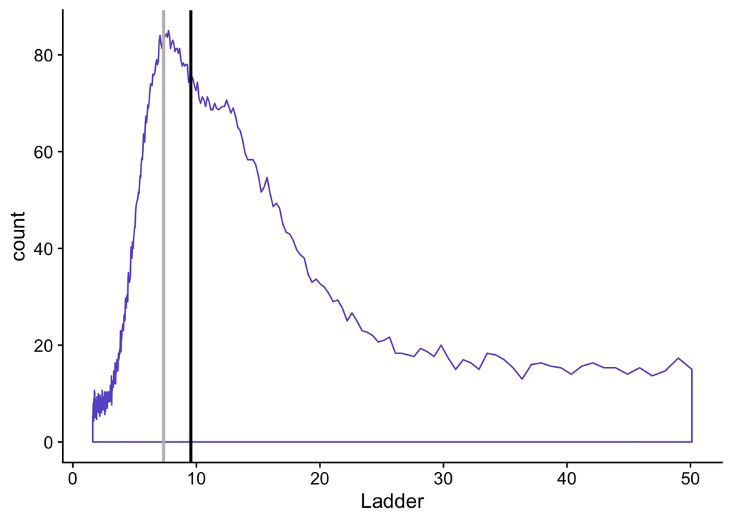

```r
ggplot(avgs) +
  geom_density(aes(x=Ladder, y=X1), fill="", color = "slateblue3", stat="identity", alpha=.3) +
  geom_vline(aes(xintercept = get_mean(Ladder, X1)), col='black', size=1) +
  geom_vline(aes(xintercept = get_median(Ladder, X1)), col='grey', size=1) +
  ylab("count") +
  theme_cowplot()
```

As you can see, means and medians give us different visualizations of the data. Since our data is so right skewed, it doesn’t make sense to rely on the mean as a proper descriptive statistic. Means are important descriptive statistics for normally distributed data; however, in this context with non-normally distributed data, it makes more sense to rely on medians.

In this dataset, if only given one value to represent an entire bird’s telomere length, it is important that the value properly represents the bird. Otherwise, a false sense of health may be attributed to the bird. In this case, the mean is much higher than the median, which may falsely lead readers to believe that the bird has much longer telomeres that it does.

So since this data is skewed, a better representation is the median.

Many statistical tests that can compare means between treatment groups and thus tell us if they are significantly different from each other rely on the fact that the data are normally distributed. In order to use these tests, we must first transform the data to create a normal distribution using log10.

Let’s try to log10 transform the ladder in the avgs dataset for a more normal distribution and plot it. The code used to create the normalized dataset is a simple asignment.

```r
avgs$N_Ladder <- log10(avgs$Ladder)
```

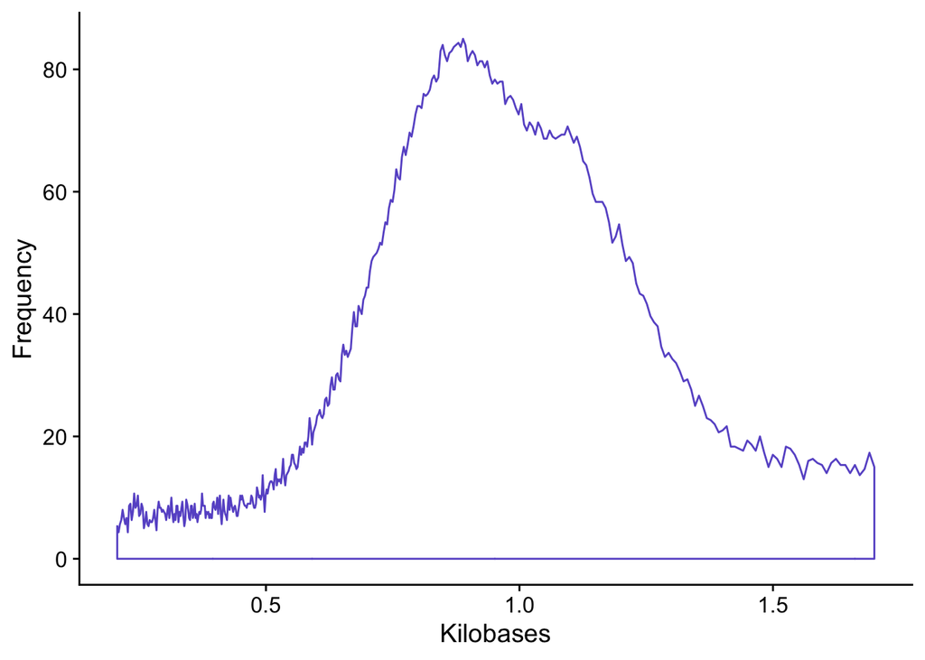

```r
logmean1 <- log10(get_mean(avgs$Ladder, avgs$X1))
ggplot(avgs) +
  geom_density(aes(x=N_Ladder, y=X1), color = "slateblue3", stat="identity", alpha=.3) +

  ylab("Frequency") +
  xlab("Kilobases") +
  theme_cowplot()
```

Below, we calculate the bird means.

```r
mean1 <- get_mean(avgs$Ladder, avgs$X1)
mean2 <- get_mean(avgs$Ladder, avgs$X2)
mean3 <- get_mean(avgs$Ladder, avgs$X3)
mean4 <- get_mean(avgs$Ladder, avgs$X4)
mean5<- get_mean(avgs$Ladder, avgs$X5)
mean6 <- get_mean(avgs$Ladder, avgs$X6)
mean7 <- get_mean(avgs$Ladder, avgs$X7)
mean8<- get_mean(avgs$Ladder, avgs$X8)
mean9 <- get_mean(avgs$Ladder, avgs$X9)
means <- c(mean1, mean2, mean3, mean4, mean5, mean6, mean7, mean8, mean9)
means
```

```
## [1]  9.553050 10.079188  9.336831  8.659835  8.351835  8.956781  8.785194
## [8]  7.205308  7.921736
```

```r
BirdID <- c("X1", "X2", "X3", "X4", "X5", "X6", "X7", "X8", "X9")
BirdID
```

```
## [1] "X1" "X2" "X3" "X4" "X5" "X6" "X7" "X8" "X9"
```

We can now overlay all nine individuals to see how they compare on this normalized scale. This can give us an idea of how different individuals are from each other within this dataset. It’s important to note these are all individuals from the same treatment group; we expect them to have similar telomere distributions.

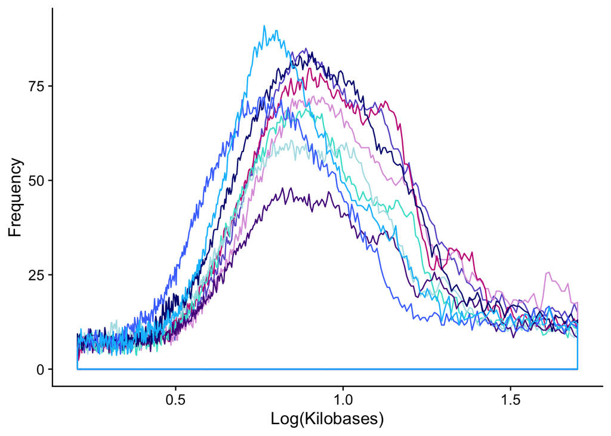

```r
ggplot(avgs) +
  geom_density(aes(x= N_Ladder, y=X1), fill="", color = "slateblue3", stat="identity", alpha=.3) +
  geom_density(aes(x= N_Ladder, y=X2), fill="", color = "plum", stat="identity", alpha=.3) +
  geom_density(aes(x= N_Ladder, y=X3), fill="", color = "mediumvioletred", stat="identity", alpha=.3) +
  geom_density(aes(x= N_Ladder, y=X4), fill="", color = "turquoise", stat="identity", alpha=.3) +
  geom_density(aes(x= N_Ladder, y=X5), fill="", color = "powderblue", stat="identity", alpha=.3) +
  geom_density(aes(x= N_Ladder, y=X6), fill="", color = "purple4", stat="identity", alpha=.3) +
  geom_density(aes(x= N_Ladder, y=X7), fill="", color = "navyblue", stat="identity", alpha=.3) +
  geom_density(aes(x= N_Ladder, y=X8), fill="", color = "royalblue1", stat="identity", alpha=.3) +
  geom_density(aes(x= N_Ladder, y=X9), fill="", color = "deepskyblue", stat="identity", alpha=.3) +
  ylab("Frequency") +
  xlab("Log(Kilobases)") +
  theme_cowplot()
```

```r
shapiro.test(means)
```

```
##
##  Shapiro-Wilk normality test
##
## data:  means
## W = 0.98947, p-value = 0.9953
```

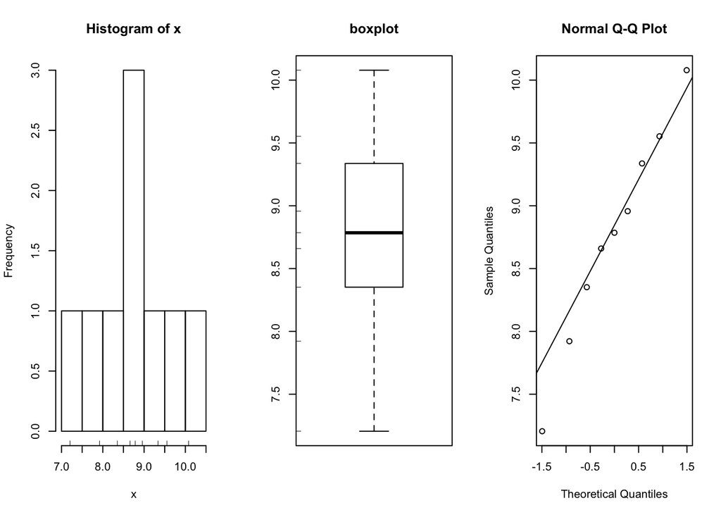

```r
simple.eda(means)
```

We know that the means within this treatment group are relatively similar, which makes sense. The Shapiro test lets us know that the mean telomere lengths are normally distributed. This is really important, especially given our small sample size of 9. Proceeding with comparisons with other treatment can follow.

```r
median1 <- get_median(avgs$Ladder, avgs$X1)
median2 <- get_median(avgs$Ladder, avgs$X2)
median3 <- get_median(avgs$Ladder, avgs$X3)
median4 <- get_median(avgs$Ladder, avgs$X4)
median5<- get_median(avgs$Ladder, avgs$X5)
median6 <- get_median(avgs$Ladder, avgs$X6)
median7 <- get_median(avgs$Ladder, avgs$X7)
median8<- get_median(avgs$Ladder, avgs$X8)
median9 <- get_median(avgs$Ladder, avgs$X9)
medians <- c(median1, median2, median3, median4, median5, median6, median7, median8, median9)
medians
```

```
## [1] 7.346963 7.500006 7.199141 6.593030 6.293760 6.531179 6.719871 5.228153
## [9] 5.913777
```

```r
shapiro.test(medians)
```

```
##
##  Shapiro-Wilk normality test
##
## data:  medians
## W = 0.95367, p-value = 0.7303
```

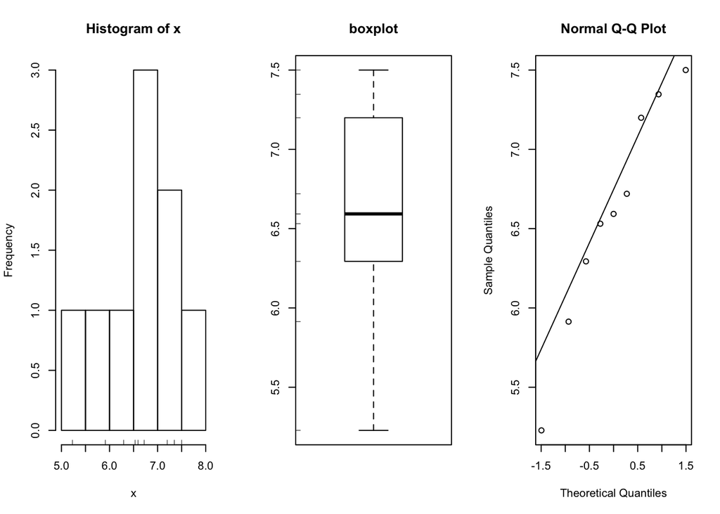

```r
simple.eda(medians)
```

In conclusion, we’ve worked to create a tutorial for Dr. Mark Haussmann’s research lab for visualizing telomere length distribution. We can effectively deal with this data by creating codes for proper means and medians. Normal distrubutions between means and medians allow us to be confident that comparison between treatment groups will be successful.